# Canal Escoadouro: Aplicação e Verificação

Bioengenharia de Solos

Prof. Dr. Luiz Diego Vidal Santos

## Abertura Exercício Completo de Canal Escoadouro

Caso didático Perímetro da Ribeira (adaptado)

- **Uso agrícola:** talhão de milho em sucessão com feijão.
- **Solo:** Planossolo com contraste textural.
- **Dimensões e relevo:** $400 \times 200\text{ m} = 8\text{ ha}$; declividade do terreno de $8\%$.

Objetivo do exercício Pré-dimensionamento verificável

Produzir um **pré-dimensionamento verificável**, distinguindo rigorosamente os **dados do enunciado** das **hipóteses adotadas** para completar os cálculos.

Planossolo · Contraste EB/Bt Área = 8 ha Sensibilidade de Manning Perfil Longitudinal

## Roteiro Fluxograma Iterativo de Dimensionamento

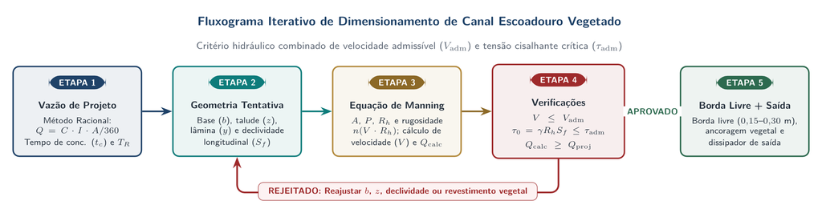

Fluxograma iterativo de dimensionamento de canal escoadouro vegetado

Fluxograma iterativo: vazão de projeto → geometria tentativa → Manning → verificações $V/\tau_0$ → borda livre e saída Critério hidráulico combinado de velocidade admissível ($V_{\mathrm{adm}}$) e tensão cisalhante crítica ($\tau_{\mathrm{adm}}$)

# Diagnóstico e dados de entrada

## Solo Perfil do Solo: Manter e Interpretar os Dados

| Atributo | Ap | E | EB | Bt |
| --- | --- | --- | --- | --- |
| **Matéria orgânica ($\text{dag kg}^{-1}$)** | 3,6 | 1,3 | 0,8 | 0,8 |
| **Areia grossa (%)** | 2 | 1 | 1 | 1 |
| **Areia fina (%)** | 12 | 11 | 9 | 3 |
| **Argila (%)** | 15 | 17 | 20 | 45 |
| **Silte (%)** | 71 | 71 | 70 | 51 |

As frações granulométricas somam $100\%$ em cada horizonte. **Investigar:** contraste EB/Bt, drenagem, dispersividade e resistência à erosão — a classe pedológica orienta essas perguntas, mas não fornece valores hidráulicos ou geotécnicos.

## Parâmetros O que é Dado e o que é Hipótese

| Entrada | Valor usado | Condição |
| --- | --- | --- |
| **Área contribuinte** | $8\text{ ha}$ | Enunciado |
| **Declividade inicial do canal** | $6\%$ | Enunciado; verificar |
| **Período de retorno** | $5\text{ anos}$ | Enunciado; discutir consequência de falha |
| **Chuva média anual** | $950\text{ mm}$ | Enunciado; não substitui IDF |
| **Intensidade $i$** | $190\text{ mm h}^{-1}$ | Hipótese didática, a substituir pela IDF e por $t_c$ |
| **Coeficiente $C$** | $0{,}58$ | Hipótese didática |
| **Manning $n$** | $0{,}035;\; 0{,}050;\; 0{,}080$ | Cenários de sensibilidade |

Os valores adotados como hipótese didática não constituem calibração nem recomendação regional.

## Etapa 1 Organização dos Terraços

Para praticar a geometria, adote preliminarmente $EV = 1{,}0\text{ m}$:

$$EH = \frac{100 \times 1{,}0}{8} = 12{,}5\text{ m}$$

- Em $200\text{ m}$ de rampa horizontal, há $16$ intervalos de $12{,}5\text{ m}$.
- A faixa retangular de $400 \times 12{,}5\text{ m}$ tem $0{,}5\text{ ha}$.

Cuidados na Etapa 1 Limites e hidrograma

- O número final de obras depende do levantamento e dos limites.
- O $EV$ preliminar precisa de critério regional e verificação hidráulica.
- Dimensione o canal final para a contribuição delimitada; não arredonde e acumule picos de terraços sem avaliar o **tempo de resposta**.

## Etapa 2 Vazão de Projeto

Com as hipóteses do exercício:

$$Q_p = \frac{C\,i\,A_b}{360} = \frac{0{,}58 \times 190 \times 8}{360}$$
$$Q_p = 2{,}449\text{ m}^3\,\text{s}^{-1}$$

Verificações anteriores ao uso em campo Validação hidrológica

1. Intensidade obtida de **equação IDF** válida para o local.
2. Duração compatível com o **tempo de concentração** ($t_c$).
3. $C$ representativo da cobertura, solo e condição hídrica.
4. Método adequado à escala, ao armazenamento e à área contribuinte.

# Testar e revisar a solução

## Etapa 3 Teste do Traçado com 6%

Seção e parâmetros de teste $b = 4{,}0\text{ m}$, $z = 2\text{ H}:1\text{ V}$, $n = 0{,}050$, $S_f = 0{,}06$

Resolvendo Manning para $Q_p = 2{,}449\text{ m}^3\,\text{s}^{-1}$:

| Resultado | Valor |
| --- | --- |
| **Profundidade normal $y$** | $0{,}281\text{ m}$ |
| **Área molhada $A_h$** | $1{,}281\text{ m}^2$ |
| **Velocidade $V$** | $1{,}912\text{ m s}^{-1}$ |
| **Tensão média $\tau_0$** | $143{,}5\text{ Pa}$ |
| **Froude $Fr$** | $1{,}22$ |

Diagnóstico: REJEITADO Excede limites admissíveis

Para limites didáticos $V_{\mathrm{adm}} = 1{,}35\text{ m s}^{-1}$ e $\tau_{\mathrm{adm}} = 50\text{ Pa}$, o teste a $6\%$ **não atende** ($V$ e $\tau_0$ muito acima e regime supercrítico $Fr = 1{,}22$).

Os limites também precisam de comprovação para o sistema solo–revestimento.

## Etapa 4 Revisão do Perfil Longitudinal

Compatibilidade topográfica Teste com $S_f = 0{,}01$ (1%)

Investigue um trecho com $S_f = 0{,}01$ ($1\%$) e a mesma base e taludes:

- Um trecho de $200\text{ m}$ a $6\%$ perde **$12\text{ m}$** de cota.
- O mesmo comprimento a $1\%$ perde apenas **$2\text{ m}$**.
- Os **$10\text{ m}$** restantes exigem outro traçado ou **estruturas de queda e dissipação**.
- Para perder $12\text{ m}$ continuamente a $1\%$, seriam necessários **$1.200\text{ m}$** de desenvolvimento.

Regra de projeto Realismo geométrico

Não reduza a declividade apenas na planilha: **demonstre o perfil executável** e dimensione transições e dissipadores. O exemplo seguinte verifica o trecho uniforme de $1\%$.

## Etapa 5 Seção para a Capacidade de Condução

Adote, para teste, profundidade útil de $0{,}65\text{ m}$ e o cenário de maior rugosidade, $n = 0{,}080$ (com $b = 4\text{ m}$, $z = 2$, $S_f = 0{,}01$):

$$A_h = (4 + 2 \times 0{,}65) \times 0{,}65 = 3{,}445\text{ m}^2 \qquad P_m = 4 + 2 \times 0{,}65\sqrt{5} = 6{,}907\text{ m}$$
$$R_h = 0{,}499\text{ m} \qquad V = 0{,}786\text{ m}\,\text{s}^{-1}$$
$$Q_{\mathrm{cap}} = 3{,}445 \times 0{,}786 = 2{,}708\text{ m}^3\,\text{s}^{-1}$$

Como $Q_{\mathrm{cap}} = 2{,}708 > Q_p = 2{,}449\text{ m}^3\,\text{s}^{-1}$ nesse estado, a seção atende à capacidade. A profundidade de $0{,}65\text{ m}$ é o limite útil adotado; a profundidade normal será menor.

## Etapa 6 Sensibilidade à Rugosidade

| $n$ | $y$ normal ($\text{m}$) | $V$ ($\text{m s}^{-1}$) | Tensão média ($\text{Pa}$) | $Fr$ |
| --- | --- | --- | --- | --- |
| $0{,}035$ | $0{,}384$ | $1{,}337$ | $31{,}4$ | $0{,}74$ |
| $0{,}050$ | $0{,}471$ | $1{,}052$ | $37{,}4$ | $0{,}53$ |
| $0{,}080$ | $0{,}614$ | $0{,}762$ | $46{,}7$ | $0{,}35$ |

Para $Q_p = 2{,}449\text{ m}^3\,\text{s}^{-1}$, $b = 4\text{ m}$, $z = 2$ e $S_f = 0{,}01$: a **maior rugosidade** governa a lâmina ($0{,}614\text{ m}$); a **menor rugosidade** governa a velocidade ($1{,}337\text{ m s}^{-1}$). A margem frente a $1{,}35\text{ m s}^{-1}$ é pequena: outros estados podem exigir nova geometria ou revestimento.

## Etapa 7 Borda Livre e Largura Superior

Como hipótese de desenho, acrescente $0{,}20\text{ m}$ de borda livre à profundidade útil de $0{,}65\text{ m}$:

$$H = 0{,}65 + 0{,}20 = 0{,}85\text{ m}$$
$$B_{\mathrm{topo}} = b + 2 z H = 4 + 2 \times 2 \times 0{,}85 = 7{,}40\text{ m}$$

Folga efetiva e validação Cenário $n = 0{,}080$

No cenário $n = 0{,}080$, a lâmina normal é $0{,}614\text{ m}$; portanto, a diferença até o coroamento é aproximadamente **$0{,}236\text{ m}$**.

Borda livre, largura, taludes e resistência precisam ser confirmados para sedimento, manutenção, recalque e condições locais.

# Implantação, quantidades e acompanhamento

## Etapa 8 Quantitativos do Trecho

Seção geométrica até $H = 0{,}85\text{ m}$:

$$A_{\mathrm{geom}} = (4 + 2 \times 0{,}85) \times 0{,}85 = 4{,}845\text{ m}^2$$

Área aproximada do revestimento por metro de canal:

$$P_{\mathrm{rev}} = 4 + 2 \times 0{,}85\sqrt{5} = 7{,}801\text{ m}$$

Estimativa para 100 m e orçamento Trecho uniforme

Para um **trecho uniforme de $100\text{ m}$**, isso corresponde a **$484{,}5\text{ m}^3$** de prisma geométrico e **$780{,}1\text{ m}^2$** de superfície interna.

O volume real de corte e aterro depende das seções do terreno. Acrescente transições, sobreposições, perdas e estruturas complementares ao orçamento.

## Etapa 9 Sequência de Execução

**1.** Confirmar levantamento, perfil, acesso e destino da descarga.

**2.** Construir saída e dissipação previstas.

**3.** Locar e conformar a seção; separar material superficial adequado.

**4.** Controlar cotas, zonas de compactação e camada para raízes.

**5.** Implantar revestimento e proteção temporária.

**6.** Liberar a contribuição conforme o desempenho previsto para a fase inicial.

**7.** Registrar seção e cobertura e inspecionar após chuvas.

## Etapa 10 Decisão e Relatório

Condicionantes executivos O que falta validar

O trecho a $1\%$ atende aos testes numéricos **apenas sob as hipóteses adotadas**. A solução executiva ainda depende de:

- IDF, tempo de concentração e coeficiente de escoamento locais.
- Limites de resistência documentados para solo, vegetação e proteção inicial.
- Perfil longitudinal completo, transições e dissipação dos desníveis.
- Estabilidade dos taludes, nível d’água e saída.
- Quantitativos reais, custos e plano de manutenção.

Entrega técnica Composição do relatório

- Memorial de cálculo
- Tabela de sensibilidade ($n$)
- Planta e perfil longitudinal
- Seção transversal tipo
- Justificativa das revisões

## Referências Leituras e Fontes Técnicas

Referências de apoio Hidráulica e análises de solo

- [USDA-NRCS (2007). *National Engineering Handbook*, Part 654, Chapter 8: Threshold Channel Design](https://directives.nrcs.usda.gov/sites/default/files2/1712931093/7332.pdf)
- [Embrapa (2017). *Manual de métodos de análise de solo*, 3ª edição](https://www.embrapa.br/web/solos/busca-de-publicacoes/-/publicacao/1085209/manual-de-metodos-de-analise-de-solo)